# (Covid19 Investigation)

## by (Junko Omata)

## Investigation Overview

> Would like to investigate on what variant is actively affecting new_cases, and possibly what element is saving us ... from wide spread of new_cases numbers and ultimately deaths_numbers

### new_cases numbers vs people_fully_vaccinated_per_hundred ---> is vaccine suppressing new cases?

> people_fully_vaccinated_per_hundred is effectively percentage value, so I use this as to understand vaccine coverage ratio

> Intresting to see the relationship of new_cases_per_million vs total_deaths_per_million

> Also intresting to see any of sociological and medical variables have any affect on new_cases numbers, e.g. population_density, median_age, gdp_capital, hospital_beds_per_thousand, cardiovasc_death_rate, diabetes_prevalance

## what is going on world wide 2021?

First checking on new_cases_per_million for this year and last year

Is there any seasonal trend?

Is it currently going down in new cases?

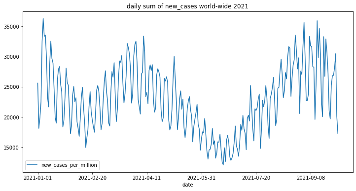

### How is vaccination coverage doing world-wide?

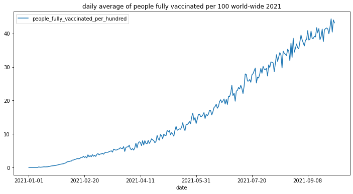

### Previous Year

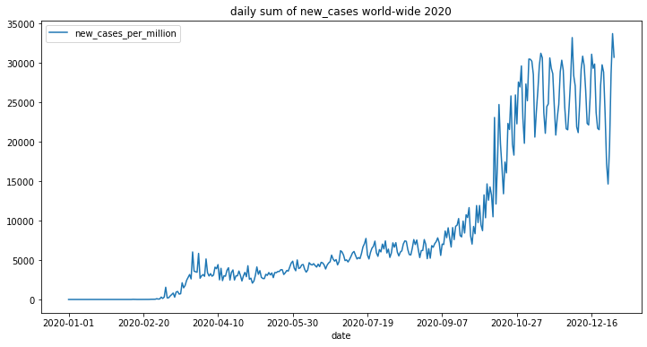

### NEXT checking on new_cases_per_million and people_fully_vaccinated_per_hundred

fully vaccination rate goes up new cases generally goes down... apart from some outlier flare ups

Note above 80/100 vaccination rate, is is celar that new cases are suppressed low

### close-up around 80/100 vaccine cover and even closer...

Closed up look around 80/100 fully vaccinated above 70, new_cases are suppressed under 800/day, above 80, under 200/day

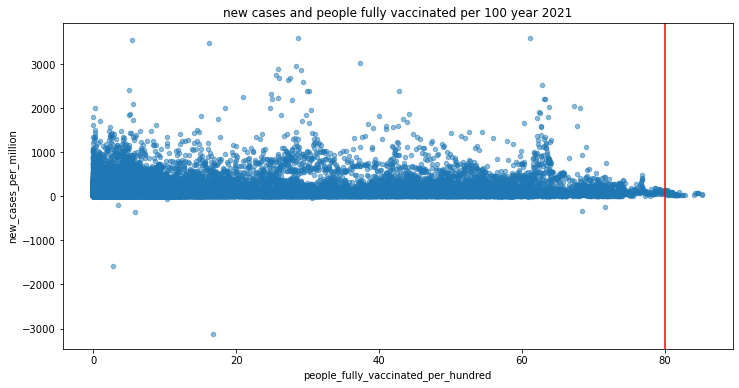

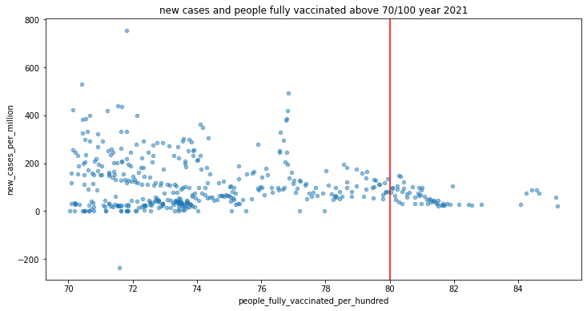

### More close-up data ... from 2021 September to 3rd October

Go-ing down

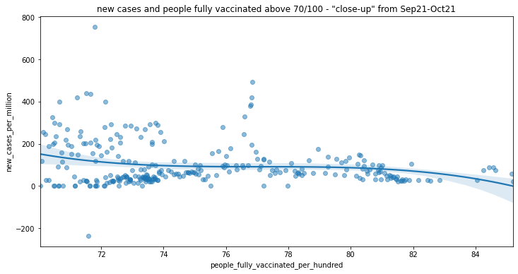

### Upsurge of the new_cases --- diabetes_prevalence

#### Upsurge in green

Diabetic_level high group is having upward trend... against other groups trending down

Upsurge is due to diabetic=high, older_generation=moderate-mixed, smoker=low, therefore it is safe to say diabetic level is a factor strongly affecting new_cases upsurge

Around 76/100 fully vaccinated, clear upsurge in green observed, needing more investigation

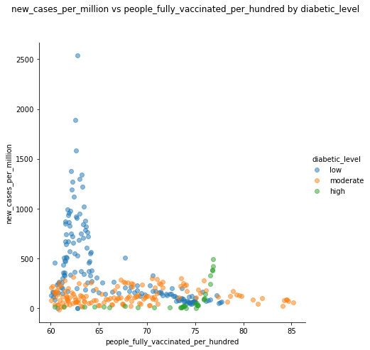

### Diabetic Level and cardio mortality level combo -- new trend at 30/100 and 40/100 ***

this combo is showing few curious upward surges strongly than 70/100 upsurge (Boris Johnson curve)

This trend group is having cardio-high/diabetic-moderate combination

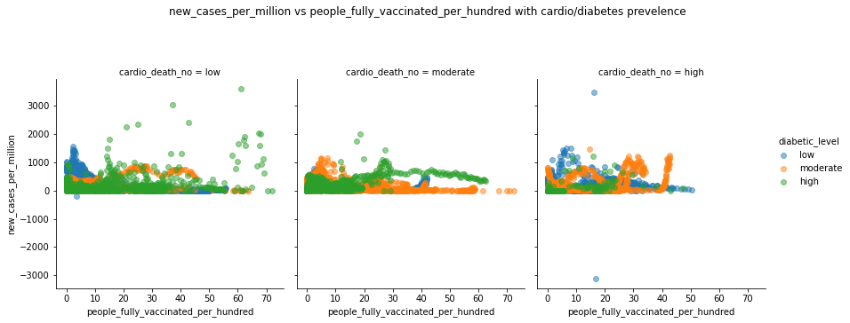

### Multiple Whammy + smoking...

could this be adverse effect of vaccine or new variant's emerging ? Could this be people refrained from taking vaccines with medical advises?

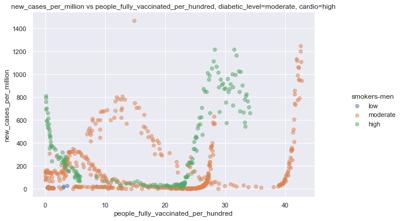

### Multiple Whammy group at a glance

| location | total_deaths_per_million | hospital_beds_per_thousand | tests_per_case | positive_rate | median_age | life_expectancy | aged_65_older |
| --- | --- | --- | --- | --- | --- | --- | --- |
| Libya | 462.430933 | 3.700 | NaN | NaN | 29.0 | 72.91 | 4.424 |
| Montenegro | 2122.394444 | 3.861 | NaN | NaN | 39.1 | 76.88 | 14.762 |
| Romania | 1252.511588 | 6.892 | 9.062205 | 0.124142 | 43.0 | 76.05 | 17.850 |
| Serbia | 831.643005 | 5.609 | 5.572131 | 0.207481 | 41.2 | 76.00 | 17.366 |

### Location of Multiple Whammies

[figure not shown]

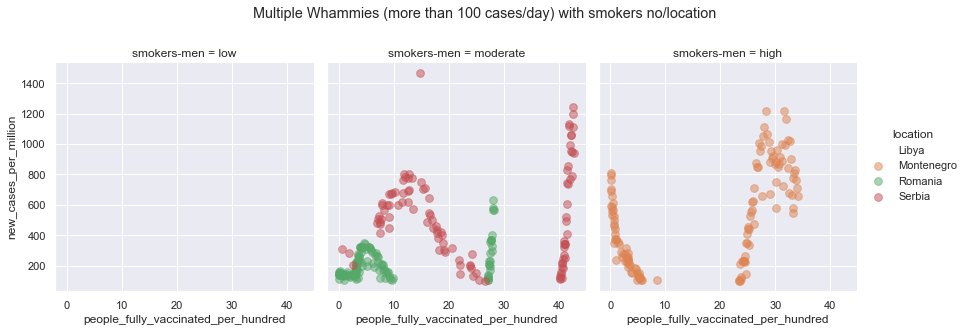

### investigating on nasty spikes new_cases_per_million more than 100

Observed nasty spike data are originated in the neighbourhood region of Romania, Serbia, Montenegro, Libya

Referencing on google map to see how closely they are located, except Libya on the other side of the African continent

They share moderate to high cardio, diabetes and smoking habit

I wonder if these upward trend could be due to having new variants, adverse effect from vaccine or FIFAe World Cup succor match clusters, even possibly manual workers/track drivers came home from EU ??

Afghanistan and Uzubekistan could be in the same situation but escaped by having younger population

### Reverse trend in central Balkan 2021

Upsurge is happening NOW despite vaccines --- focusing on new_cases

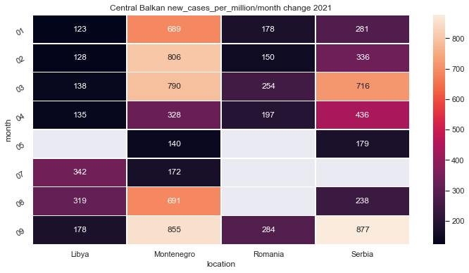

### Reverse upward trend in central Balkan 2021

Upsurge is happening NOW despite vaccines --- focusing on new_deaths

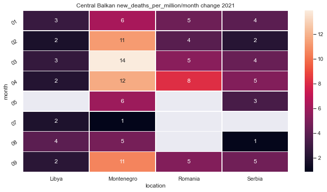

### Full Vaccination rate goes up, new_cases goes down except....

Generally there were negative co-relationship between people_fully_vaccinated_per_hundred and new_cases_per_million, showing vaccination rate goes up, new_cases goes down however there were some upsurge in Central Balkan

### Quad whammy found!

Not only diabetic_prevalence, also cardiovasc_death_rate, age and smoker numbers strongly affected of jumping surge of new_cases to the point of being reverse trend despite vaccines

Reverse trend was localized in area of Romania, Serbia, Montenegro and Libya

For Reverse trend group, full vaccination rate remained around 40/100 to this date